# Tropical Storm Beatriz

#### Wind Profile

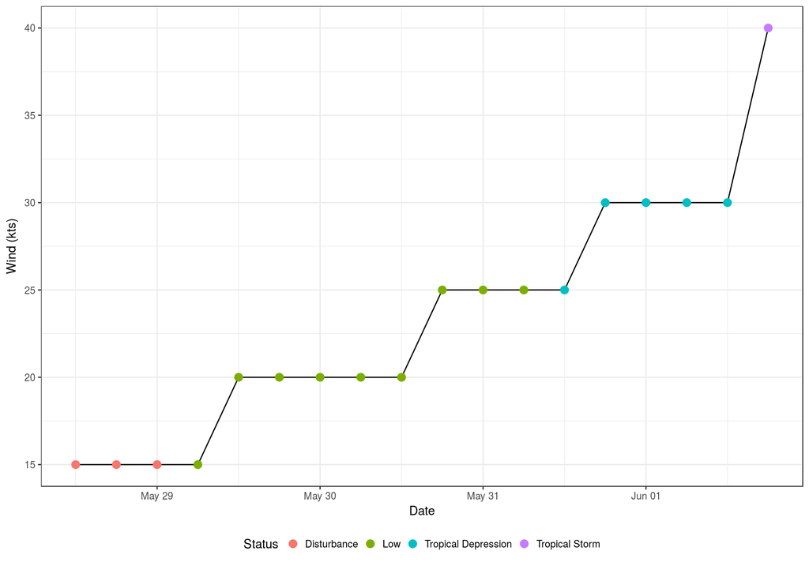

```r
# Plot wind values
wind_press %>% ggplot(aes(x = Date, y = Wind)) +
    geom_line() +
    geom_point(aes(color = Status), size = 3) +
    scale_y_continuous(name = "Wind (kts)") +
    theme_bw() +
    theme(legend.position = "bottom")
```

#### Pressure Profile

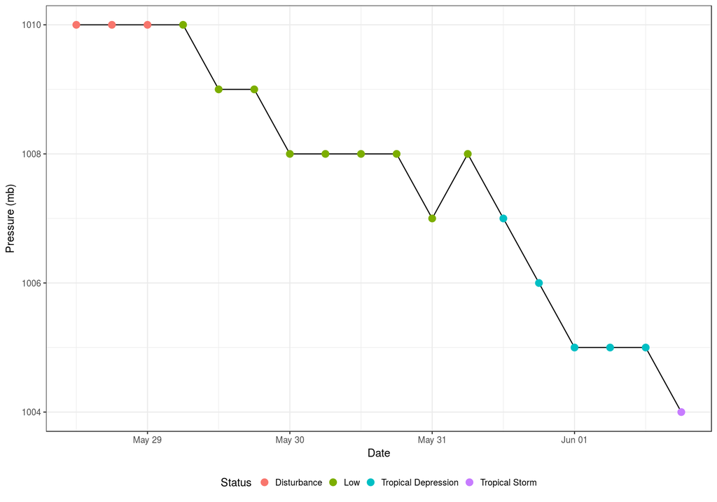

```r
# Plot pressure values
wind_press %>% ggplot(aes(x = Date, y = Pressure)) +
    geom_line() +
    geom_point(aes(color = Status), size = 3) +
    scale_y_continuous(name = "Pressure (mb)") +
    theme_bw() +
    theme(legend.position = "bottom")
```

#### Wind/Pressure Relational Change

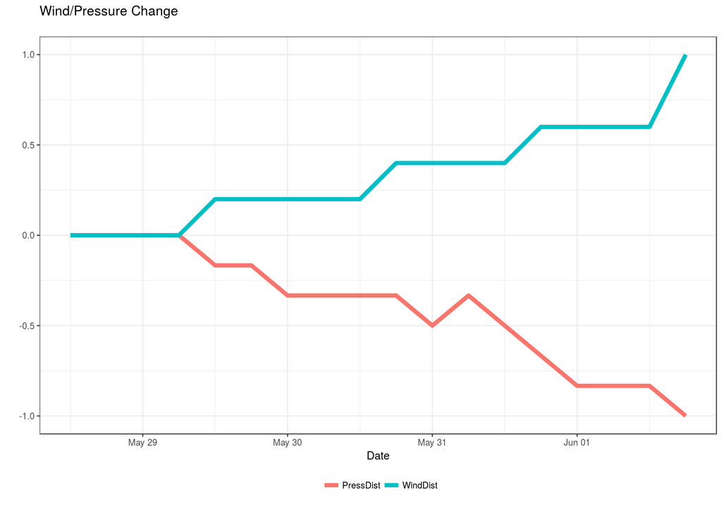

```r
wind_press_cum %>% ggplot(aes(x = Date, y = Val, group = Var, color = Var)) +
    geom_line(size = 2) +
    theme_bw() +
    theme(legend.position = "bottom", legend.title = element_blank()) +
    labs(title = "Wind/Pressure Change",
         subtitle = "",
         y = "")
```

### Public Advisory Statement

…BEATRIZ DEGENERATES TO A REMNANT LOW PRESSURE AREA… …POTENTIAL FOR LIFE-THREATENING FLASH FLOODS CONTINUES IN THE MEXICAN STATE OF OAXACA…

SUMMARY OF 1000 AM CDT…1500 UTC…INFORMATION

LOCATION…17.2N 96.1W ABOUT 105 MI…170 KM NNE OF PUERTO ANGEL MEXICO MAXIMUM SUSTAINED WINDS…25 MPH…35 KM/H PRESENT MOVEMENT…NNE OR 20 DEGREES AT 7 MPH…11 KM/H MINIMUM CENTRAL PRESSURE…1007 MB…29.74 INCHES

WATCHES AND WARNINGS

There are no coastal watches or warnings in effect.

DISCUSSION AND 48-HOUR OUTLOOK

At 1000 AM CDT (1500 UTC), the center of Post-Tropical Cyclone Beatriz was located near latitude 17.2 North, longitude 96.1 West. The post-tropical cyclone is moving toward the north-northeast near 7 mph (11 km/h) and this motion is expected to continue through tonight. On the forecast track, the remnant low should move across southern Mexico through tonight.

Maximum sustained winds are near 25 mph (35 km/h) with higher gusts. The cyclone is expected to dissipate tonight over southern Mexico.

The estimated minimum central pressure is 1007 mb (29.74 inches).

HAZARDS AFFECTING LAND

RAINFALL: The remnants of Beatriz are expected to produce additional rainfall of 2 to 5 inches over portions of the Mexican state of Oaxaca with isolated maximum storm total amounts of 18 inches possible. While rainfall intensity will be on a decreasing trend today, the potential for life-threatening flash floods and mudslides will continue. Lighter rainfall amounts in the 1 to 3 inch range are possible across the southern portion of the Mexican state of Veracruz.

NEXT ADVISORY

This is the last public advisory issued by the National Hurricane Center on this system.

## Forecast

[figure not shown]

```r
# If any of necessary datasets exist, copy base plot to current plot
if (any(exists("fcst_lin"), exists("fcst_pts"), exists("fcst_pgn")))
    fp <- bp

## ---- 5-day forecast line ----------------------------------------------------
if (exists("fcst_lin")) {
    p_fcst_lin <- geom_path(data = fcst_lin, aes(x = long, y = lat))
    fp <- fp + p_fcst_lin
}

## ---- 5-day forecast points --------------------------------------------------
if (exists("fcst_pts")) {
    p_fcst_pts <- geom_point(data = fcst_pts,
                                 aes(x = LON.x, y = LAT.x, color = TCDVLP.x,
                                     size = MAXWIND.x))
    fp <- fp + p_fcst_pts
}

## ---- 5-day forecast polygon -------------------------------------------------
if (exists("fcst_pgn")) {
    p_fcst_pgn <- geom_polygon(data = fcst_pgn,
                                  aes(x = long, y = lat,
                                      fill = as.factor(FCSTPRD)),
                                  alpha = 0.3)
    fp <- fp + p_fcst_pgn
}

# Print forecast plot
if (exists("fp")) fp
```

```r
kable(fcst, caption = sprintf("%s Forecast", storm_vars$name))
```

Tropical Storm Beatriz Forecast

| FcstDate | Lat | Lon | Wind | Gust | Category |
| --- | --- | --- | --- | --- | --- |
| 2017-06-03 | 18.1 | -95.7 | 20 | 30 | TD |

### Cumulative Wind Speed Probabilities

#### 0.5-Degree Resolution

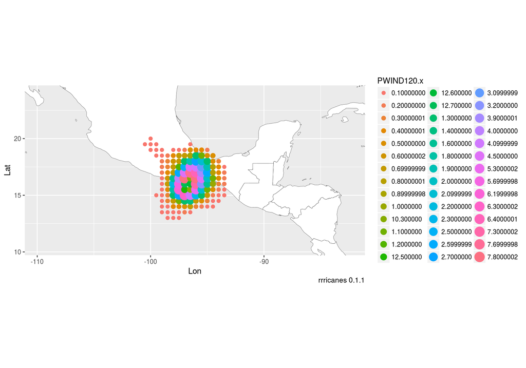

Wind Speed Probabilities (>= 34kts)

```r
if (exists("wsp34_half")) {
    p_wsp34_half <- geom_point(data = wsp34_half,
                               aes(x = coords.x1, y = coords.x2,
                                   size = PWIND120.x, color = PWIND120.x))
    wsp + p_wsp34_half
}
```

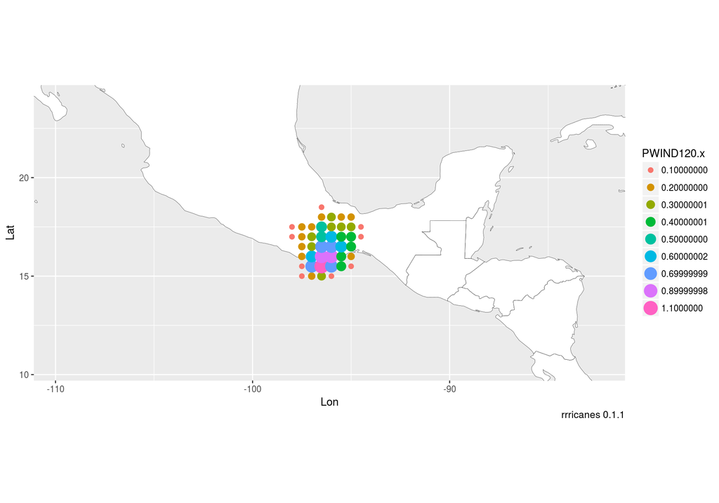

Wind Speed Probabilities (>= 50kts)

```r
if (exists("wsp50_half")) {
    p_wsp50_half <- geom_point(data = wsp50_half,
                               aes(x = coords.x1, y = coords.x2,
                                   size = PWIND120.x, color = PWIND120.x))
    wsp + p_wsp50_half
}
```

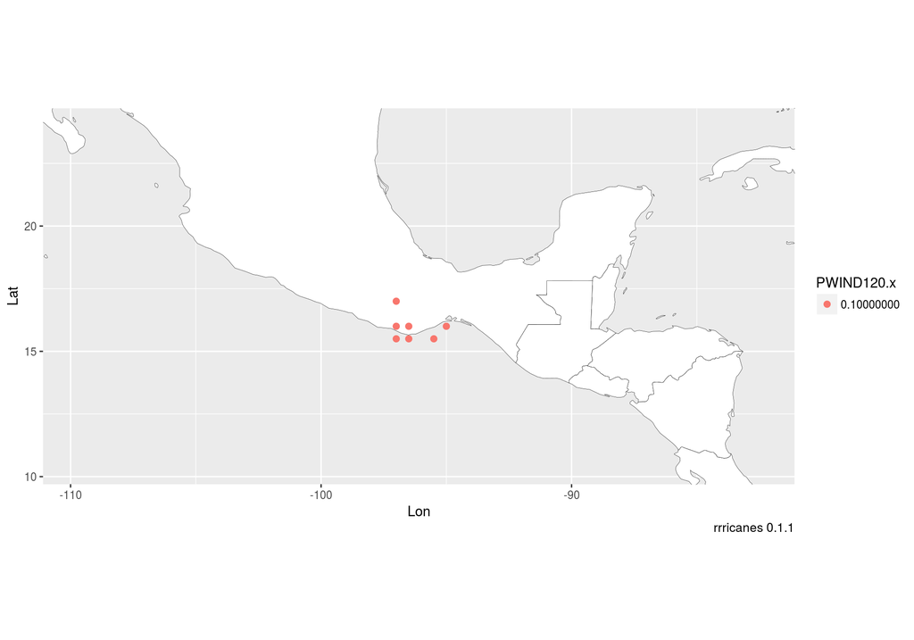

Wind Speed Probabilities (>= 64kts)

```r
if (exists("wsp64_half")) {
    p_wsp64_half <- geom_point(data = wsp64_half,
                               aes(x = coords.x1, y = coords.x2,
                                   size = PWIND120.x, color = PWIND120.x))
    wsp + p_wsp64_half
}
```

Cumulative wind speed probabilities are the sum of wind speed probablities for every forecast period issued. Below is a table (if available) of wind speed probabilities for select locations throughout each forecast period (12 hours, 24 hours, 36, 48, 72, 96 and 120).

```r
if (nrow(wndprb) > 0) {
    kable(wndprb, caption = "Wind Speed Probabilities")
} else {
    message("There are no wind speed probabilities with this advisory.")
}
```

[output not shown]

## Past Advisories

```r
kable(fstadv %>% select(Status, Adv, Date, Wind, Gust, Pressure, Eye),
      caption = sprintf("%s Advisories", storm_vars$name))
```

Tropical Storm Beatriz Advisories

| Status | Adv | Date | Wind | Gust | Pressure | Eye |
| --- | --- | --- | --- | --- | --- | --- |
| Tropical Depression | 1 | 2017-05-31 15:00:00 | 25 | 35 | 1007 | NA |
| Tropical Depression | 2 | 2017-05-31 21:00:00 | 30 | 40 | 1006 | NA |
| Tropical Depression | 3 | 2017-06-01 03:00:00 | 30 | 40 | 1005 | NA |
| Tropical Depression | 4 | 2017-06-01 09:00:00 | 30 | 40 | 1005 | NA |
| Tropical Depression | 5 | 2017-06-01 15:00:00 | 30 | 40 | 1005 | NA |
| Tropical Storm | 6 | 2017-06-01 21:00:00 | 40 | 50 | 1004 | NA |
| Tropical Storm | 7 | 2017-06-02 03:00:00 | 35 | 45 | 1004 | NA |
| Tropical Depression | 8 | 2017-06-02 09:00:00 | 30 | 40 | 1007 | NA |
| Post-Tropical Cyclone | 9 | 2017-06-02 15:00:00 | 20 | 30 | 1007 | NA |

## Storm Discussion

ZCZC MIATCDEP2 ALL TTAA00 KNHC DDHHMM

Post-Tropical Cyclone Beatriz Discussion Number 9 NWS National Hurricane Center Miami FL EP022017 1000 AM CDT Fri Jun 02 2017

Satellite imagery and surface observations indicate that Beatriz has degenerated to a poorly-defined remnant low over southern Mexico, and this will be the last advisory. While the low should dissipate over land tonight, the remnants of Beatriz are expected to move over the southwestern Gulf of Mexico during the next day or two, where current indications are that strong upper-level winds should prevent re-development.

Even after dissipation, lingering moisture is likely to contribute to continued heavy rainfall and possible flash floods and mudslides for another day or two over southern and southeastern Mexico.

FORECAST POSITIONS AND MAX WINDS

INIT 02/1500Z 17.2N 96.1W 20 KT 25 MPH…POST-TROP/REMNT LOW 12H 03/0000Z 18.1N 95.7W 20 KT 25 MPH…POST-TROP/REMNT LOW 24H 03/1200Z…DISSIPATED

$$ Forecaster Beven

NNNN

## About `rrricanes`

rrricanes is not intended for use in emergency situations.

`rrricanes` is a R package designed to get current and archived real-time data on tropical storms and hurricanes. Contributors are strongly encouraged. View the [GitHub repository](https://github.com/timtrice/rrricanes) for more information.